# Plotting a simple species distribution map based on GBIF records

### Installing and loading packages

To create our first distribution map, we need some R packages. The most relevant ones are: **terra**, to deal with spatial objects. **rgbif**, to communicate with GBIF and download occurrences. **rnaturalearth**, to load geographic data to be used in the maps.

- **terra** (Hijmans, 2023): https://CRAN.R-project.org/package=terra
- **rgbif** (Chamberlain *et al*, 2017): https://CRAN.R-project.org/package=rgbif
- **rnaturalearth** (Massicotte & South, 2023): https://CRAN.R-project.org/package=rnaturalearth

To install the packages, we will use the function `install.packages()`:

```r
install.packages(c("terra", "rgbif", "rnaturalearth"), repos="http //cran.us.r-project.org")
```

Once installed, we can load the packages using the function `library()`:

```r
library("terra")
library("rgbif")
library("rnaturalearth")
```

### Basic data query

To search for a species in the GBIF portal using `rgbif`, copy the following code into the current R script.

```r
records <- occ_search(scientificName = "Gongora bufonia", hasCoordinate = TRUE, limit = 10000)
```

We have two additional arguments here (`hasCoordinate=` and `limit=`). Find out what they mean by checking the function documentation, typing the following:

```r
??occ_search()
```

The results from our survey are stored under the sub-object `records$data`. There are many columns in this dataframe, and they follow the [DarwinCore](https://dwc.tdwg.org/terms/) format. Check the column names by typing `names()`, and find out which ones correspond to the geographic coordinates by reading the DarwinCore manual.

```r
names(records$data)
```

### Creating spatial objects

Our spatial information is stored in the columns `decimalLatitude` and `decimalLongitude`. The standard coordinate reference system used in GBIF is *World Geodetic System 1984 (WGS84)*, and the coordinates are represented as decimal values. With this information, we can now create a spatial object using these coordinates and the function `vect()`, from `terra`.

```r
points <- vect(records$data, geom=c("decimalLongitude", "decimalLatitude"), crs="+proj=longlat +datum=WGS84")
```

Now that we have our points, we also need a base layer with other useful information, like countries, continents, and oceans. We can download that directly to a spatial object using the function `ne_countries()` from the package `rnaturalearth`.

```r
south_america <- ne_countries(continent = "south america")
```

Finally, it is time to plot our map. There are many different ways of doing that, and to produce a map that is ready to publication, I recommend following the tutorial by Moreno & Basille available in the [r-spatial web portal](https://r-spatial.org/r/2018/10/25/ggplot2-sf.html). For the purpose of this tutorial, we will stick with the base plot functions.

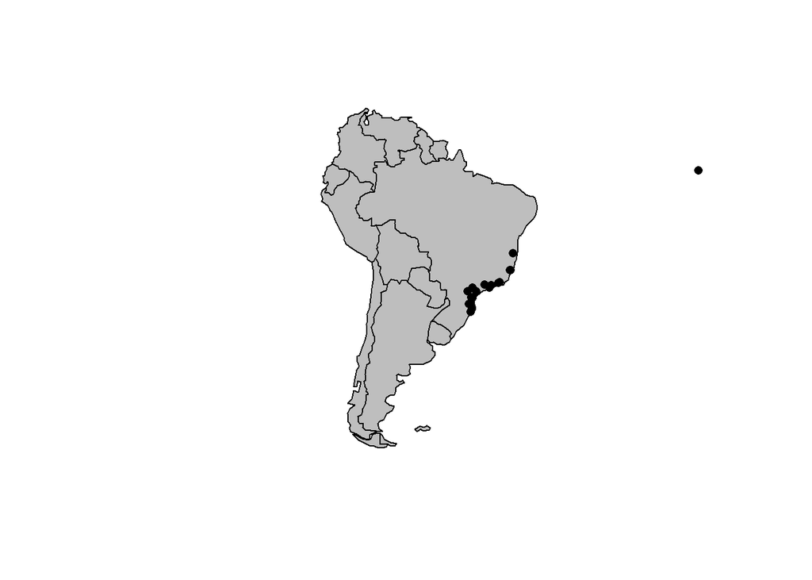

```r
plot(south_america, col="grey")
plot(points, add=T)
```

Did you notice something weird about the output? If you look carefully, you will notice a record in the middle of the Atlantic. This is something we call an *outlier*. Outliers can be caused by a variety of different errors in the process of digitization and data collection, and we will learn more about how to get rid of them in the next part of this course: *the data cleaning*.